# Name: SINA RAHINI

### Project Timeline: 6/7/2025-10/10/2025

# Introduction

The purpose of this project is to show technical skills and problem solving ability by working through something similar to a real NBA data science project. **Note:**

**Throughout this document, any `season` column represents the year each season started. For example, the 2015-16 season will be in the dataset as 2015. We may refer to a season by just this number (e.g. 2015) instead of the full text (e.g. 2015-16).**

# Answers

## Part 1

**Question 1:** 26 4-in-6 stretches in OKC's draft schedule.

**Question 2:** 25.1 4-in-6 stretches on average.

**Question 3:**

- Most 4-in-6 stretches on average: CHA (28.1)
- Fewest 4-in-6 stretches on average: NYK (22.2)

**Question 4:** This is a written question. Please leave your response in the document under Question 4.

**Question 5:**

- BKN Defensive eFG%: 54.3%
- When opponent on a B2B: 53.5%

## Part 2

Please show your work in the document, you don't need anything here.

## Part 3

**Question 9:**

# Setup and Data

```python
# %pip install numpy pandas matplotlib scipy jupyter notebook openpyxl requests schedule seaborn scikit-learn xlrd xlwt tqdm ipywidgets
```

```python
import pandas as pd
import os
# Note, you will likely have to change these paths. If your data is in the same folder as this project,
# the paths will likely be fixed for you by deleting ../../Data/schedule_project/ from each string.
user = os.getlogin()
schedule = pd.read_csv(f"C:/Users/{user}/Python Projects/Data/schedule.csv")
draft_schedule = pd.read_csv(f"C:/Users/{user}/Python Projects/Data/schedule_24_partial.csv")
locations = pd.read_csv(f"C:/Users/{user}/Python Projects/Data/locations.csv")
game_data = pd.read_csv(f"C:/Users/{user}/Python Projects/Data/team_game_data.csv")
```

```python
# Quick look at schedule dataset.
print("First few rows of schedule dataset:")
pd.set_option('display.max_columns', None)
pd.set_option('display.width', 1000)
display(schedule.head())
print("schedule variable types:")
print(schedule.dtypes)
print(schedule.info)
```

```
First few rows of schedule dataset:
```

|  | season | gamedate | team | opponent | home | win |
| --- | --- | --- | --- | --- | --- | --- |
| 0 | 2014 | 2015-04-15 | SAC | LAL | 0 | 1 |
| 1 | 2014 | 2015-04-15 | NYK | DET | 1 | 0 |
| 2 | 2014 | 2015-04-15 | DEN | GSW | 0 | 0 |
| 3 | 2014 | 2015-04-15 | MIA | PHI | 0 | 1 |
| 4 | 2014 | 2015-04-15 | UTA | HOU | 0 | 0 |

```
schedule variable types:
season       int64
gamedate    object
team        object
opponent    object
home         int64
win          int64
dtype: object
<bound method DataFrame.info of        season    gamedate team opponent  home  win
0        2014  2015-04-15  SAC      LAL     0    1
1        2014  2015-04-15  NYK      DET     1    0
2        2014  2015-04-15  DEN      GSW     0    0
3        2014  2015-04-15  MIA      PHI     0    1
4        2014  2015-04-15  UTA      HOU     0    0
...       ...         ...  ...      ...   ...  ...
23953    2023  2023-10-25  CHI      OKC     1    0
23954    2023  2023-10-24  PHX      GSW     0    1
23955    2023  2023-10-24  GSW      PHX     1    0
23956    2023  2023-10-24  DEN      LAL     1    1
23957    2023  2023-10-24  LAL      DEN     0    0

[23958 rows x 6 columns]>
```

```python
# Quick look at draft_schedule dataset.
print("First few rows of draft_schedule dataset:")
pd.set_option('display.max_columns', None)
pd.set_option('display.width', 1000)
display(draft_schedule.head())
print("draft_schedule variable types:")
print(draft_schedule.dtypes)
print(draft_schedule.info)
```

```
First few rows of draft_schedule dataset:
```

|  | season | gamedate | team | opponent | home | win |
| --- | --- | --- | --- | --- | --- | --- |
| 0 | 2024 | 2025-04-13 | DEN | HOU | 0 | 1 |
| 1 | 2024 | 2025-04-13 | OKC | NOP | 0 | 1 |
| 2 | 2024 | 2025-04-11 | OKC | UTA | 0 | 1 |
| 3 | 2024 | 2025-04-11 | DEN | MEM | 1 | 1 |
| 4 | 2024 | 2025-04-09 | OKC | PHX | 0 | 1 |

```
draft_schedule variable types:
season       int64
gamedate    object
team        object
opponent    object
home         int64
win          int64
dtype: object
<bound method DataFrame.info of      season    gamedate team opponent  home  win
0      2024  2025-04-13  DEN      HOU     0    1
1      2024  2025-04-13  OKC      NOP     0    1
2      2024  2025-04-11  OKC      UTA     0    1
3      2024  2025-04-11  DEN      MEM     1    1
4      2024  2025-04-09  OKC      PHX     0    1
..      ...         ...  ...      ...   ...  ...
155    2024  2024-10-27  OKC      ATL     1    1
156    2024  2024-10-26  OKC      CHI     0    1
157    2024  2024-10-26  DEN      LAC     1    0
158    2024  2024-10-24  DEN      OKC     1    0
159    2024  2024-10-24  OKC      DEN     0    1

[160 rows x 6 columns]>
```

```python
# Quick look at locations dataset.
print("First few rows of locations dataset:")
pd.set_option('display.max_columns', None)
pd.set_option('display.width', 1000)
display(locations.head())
print("locations variable types:")
print(locations.dtypes)
print(locations.info)
```

```
First few rows of locations dataset:
```

|  | team | latitude | longitude | timezone |
| --- | --- | --- | --- | --- |
| 0 | ATL | 33.757233 | -84.396340 | Eastern |
| 1 | BOS | 42.366310 | -71.062226 | Eastern |
| 2 | BKN | 40.682657 | -73.975282 | Eastern |
| 3 | CHA | 35.225186 | -80.839336 | Eastern |
| 4 | CHI | 41.880629 | -87.674048 | Central |

```
locations variable types:
team          object
latitude     float64
longitude    float64
timezone      object
dtype: object
<bound method DataFrame.info of    team   latitude   longitude  timezone
0   ATL  33.757233  -84.396340   Eastern
1   BOS  42.366310  -71.062226   Eastern
2   BKN  40.682657  -73.975282   Eastern
3   CHA  35.225186  -80.839336   Eastern
4   CHI  41.880629  -87.674048   Central
5   CLE  41.496577  -81.688076   Eastern
6   DAL  32.790314  -96.810148   Central
7   DEN  39.748550 -105.007711  Mountain
```

[output cut: 22 more lines]

```python
# Quick look at game_data dataset.
print("First few rows of game_data dataset:")
pd.set_option('display.max_columns', None)
pd.set_option('display.width', 1000)
display(game_data.head())
print("game_data variable types:")
print(game_data.dtypes)
print(game_data.shape)
```

```
First few rows of game_data dataset:
```

|  | season | gametype | nbagameid | gamedate | offensivenbateamid | off_team_name | off_team | off_home | off_win | defensivenbateamid | def_team_name | def_team | def_home | def_win | fg2made | fg2missed | fg2attempted | fg3made | fg3missed | fg3attempted | fgmade | fgmissed | fgattempted | ftmade | ftmissed | ftattempted | reboffensive | rebdefensive | reboundchance | … |
| --- | --- | --- | --- | --- | --- | --- | --- | --- | --- | --- | --- | --- | --- | --- | --- | --- | --- | --- | --- | --- | --- | --- | --- | --- | --- | --- | --- | --- | --- | --- |
| 0 | 2016 | 2 | 21600495 | 2016-12-30 | 1610612740 | New Orleans Pelicans | NOP | 1 | 1 | 1610612752 | New York Knicks | NYK | 0 | 0 | 26 | 30 | 56 | 12 | 17 | 29 | 38 | 47 | 85 | 16 | 1 | 17 | 6 | 42 | 48 | … |
| 1 | 2016 | 2 | 21600495 | 2016-12-30 | 1610612752 | New York Knicks | NYK | 0 | 0 | 1610612740 | New Orleans Pelicans | NOP | 1 | 1 | 28 | 42 | 70 | 7 | 16 | 23 | 35 | 58 | 93 | 15 | 1 | 16 | 15 | 43 | 58 | … |
| 2 | 2021 | 2 | 22100943 | 2022-03-03 | 1610612742 | Dallas Mavericks | DAL | 1 | 1 | 1610612744 | Golden State Warriors | GSW | 0 | 0 | 28 | 20 | 48 | 17 | 20 | 37 | 45 | 40 | 85 | 15 | 5 | 20 | 12 | 30 | 42 | … |
| 3 | 2021 | 2 | 22100943 | 2022-03-03 | 1610612744 | Golden State Warriors | GSW | 0 | 0 | 1610612742 | Dallas Mavericks | DAL | 1 | 1 | 29 | 22 | 51 | 15 | 15 | 30 | 44 | 37 | 81 | 10 | 3 | 13 | 12 | 27 | 39 | … |
| 4 | 2016 | 2 | 21601032 | 2017-03-18 | 1610612741 | Chicago Bulls | CHI | 1 | 1 | 1610612762 | Utah Jazz | UTA | 0 | 0 | 31 | 30 | 61 | 7 | 12 | 19 | 38 | 42 | 80 | 12 | 2 | 14 | 10 | 33 | 43 | … |

```
game_data variable types:
season                 int64
gametype               int64
nbagameid              int64
gamedate              object
offensivenbateamid     int64
off_team_name         object
off_team              object
off_home               int64
off_win                int64
defensivenbateamid     int64
def_team_name         object
def_team              object
def_home               int64
def_win                int64
fg2made                int64
fg2missed              int64
fg2attempted           int64
fg3made                int64
fg3missed              int64
fg3attempted           int64
fgmade                 int64
fgmissed               int64
fgattempted            int64
ftmade                 int64
ftmissed               int64
ftattempted            int64
reboffensive           int64
rebdefensive           int64
reboundchance          int64
assists                int64
stealsagainst          int64
turnovers              int64
blocksagainst          int64
defensivefouls         int64
offensivefouls         int64
shootingfoulsdrawn     int64
possessions            int64
points                 int64
shotattempts           int64
andones                int64
shotattemptpoints      int64
dtype: object
(23958, 41)
```

## Part 1 -- Schedule Analysis

In this section, you're going to work to answer questions using NBA scheduling data.

### Question 1

**QUESTION:** How many times are the Thunder scheduled to play 4 games in 6 nights in the provided 80-game draft of the 2024-25 season schedule? (Note: clarification, the stretches can overlap, the question is really “How many games are the 4th game played over the past 6 nights?”)

```python
import numpy as np

# Filter for OKC games
okc_games = draft_schedule[draft_schedule['team'] == 'OKC'].copy()
okc_games['gamedate'] = pd.to_datetime(okc_games['gamedate'])
okc_games = okc_games.sort_values('gamedate').reset_index(drop=True)

# Initialize counter for 4-in-6 stretches.
# This counts the number of games where OKC plays their 4th game in a 6-day window (including today).
count_4_in_6 = 0
dates = okc_games['gamedate']

# For each game, check if there are 3 other OKC games in the previous 5 days (6-day window including today)
for i in range(len(dates)):
    window_start = dates[i] - pd.Timedelta(days=5)
    games_in_window = ((dates >= window_start) & (dates <= dates[i])).sum()
    if games_in_window >= 4:
        count_4_in_6 += 1

print(f"OKC has {count_4_in_6} 4-in-6 stretches in the draft schedule.")
```

```
OKC has 26 4-in-6 stretches in the draft schedule.
```

**ANSWER 1:**

26 4-in-6 stretches in OKC's draft schedule.

### Question 2

**QUESTION:** From 2014-15 to 2023-24, what is the average number of 4-in-6 stretches for a team in a season? Adjust each team/season to per-82 games before taking your final average.

```python
# Ensure gamedate is datetime
schedule['gamedate'] = pd.to_datetime(schedule['gamedate'])

# Function to count 4-in-6 stretches for a team/season
def count_4_in_6_for_team(df):
    df = df.sort_values('gamedate').reset_index(drop=True)
    dates = df['gamedate']
    count = 0
    for i in range(len(dates)):
        window_start = dates[i] - pd.Timedelta(days=5)
        games_in_window = ((dates >= window_start) & (dates <= dates[i])).sum()
        if games_in_window >= 4:
            count += 1
    return count

# Group by team and season, count stretches and adjust to per-82 games
results = []
for (team, season), group in schedule.groupby(['team', 'season']):
    n_games = len(group)
    stretches = count_4_in_6_for_team(group)
    # Adjust to per-82 games
    stretches_per_82 = stretches * 82 / n_games if n_games > 0 else 0
    results.append({'team': team, 'season': season, 'stretches_per_82': stretches_per_82})

results_df = pd.DataFrame(results)

# Average across all team-seasons
average_4_in_6 = results_df['stretches_per_82'].mean()
print(f"Average number of 4-in-6 stretches per team-season (per 82 games): {average_4_in_6:.1f}")
```

```
Average number of 4-in-6 stretches per team-season (per 82 games): 25.1
```

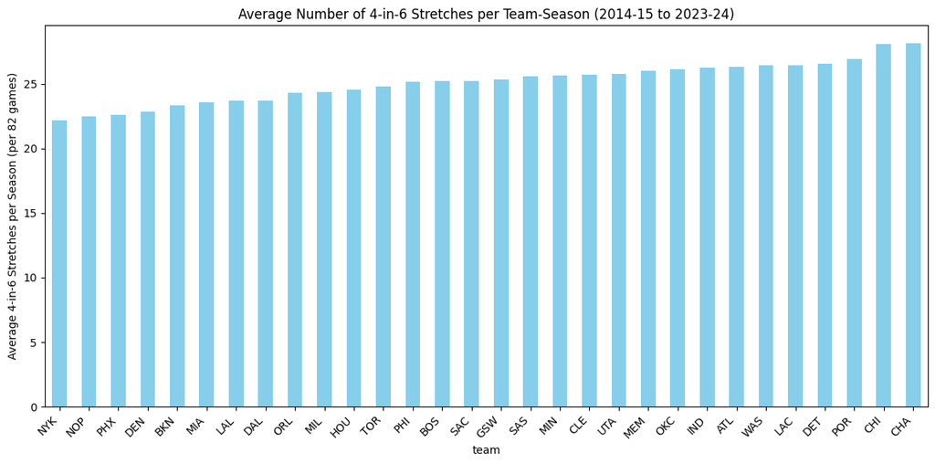

```python
import matplotlib.pyplot as plt
# Calculate average 4-in-6 stretches per team (across all seasons)
team_avg = results_df.groupby('team')['stretches_per_82'].mean()
plt.figure(figsize=(12,6))
team_avg_sorted = team_avg.sort_values()
team_avg_sorted.plot(kind='bar', color='skyblue')
plt.ylabel('Average 4-in-6 Stretches per Season (per 82 games)')
plt.title('Average Number of 4-in-6 Stretches per Team-Season (2014-15 to 2023-24)')
plt.xticks(rotation=45, ha='right')
plt.tight_layout()
plt.show()
```

**ANSWER 2:**

25.1 4-in-6 stretches on average.

### Question 3

**QUESTION:** Which of the 30 NBA teams has had the highest average number of 4-in-6 stretches between 2014-15 and 2023-24? Which team has had the lowest average? Adjust each team/season to per-82 games.

```python
# Find team with highest and lowest average 4-in-6 stretches per season (per 82 games)
most_stretches_team = team_avg.idxmax()
most_stretches_value = team_avg.max()
fewest_stretches_team = team_avg.idxmin()
fewest_stretches_value = team_avg.min()

# Printing both the team names and their average values
print(f"Most 4-in-6 stretches on average: {most_stretches_team} ({most_stretches_value:.1f})")
print(f"Fewest 4-in-6 stretches on average: {fewest_stretches_team} ({fewest_stretches_value:.1f})")
```

```
Most 4-in-6 stretches on average: CHA (28.1)
Fewest 4-in-6 stretches on average: NYK (22.2)
```

**ANSWER 3:**

- Most 4-in-6 stretches on average: CHA (28.1)
- Fewest 4-in-6 stretches on average: NYK (22.2)

### Question 4

**QUESTION:** Is the difference between most and least from Q3 surprising, or do you expect that size difference is likely to be the result of chance?

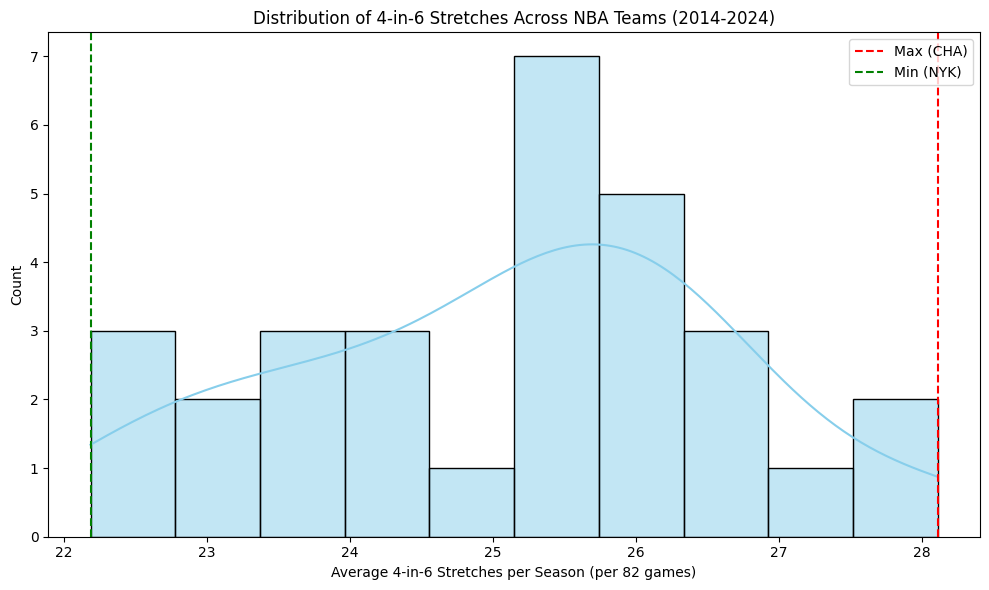

```python
import seaborn as sns

import scipy.stats as stats
import matplotlib.pyplot as plt

# Prepare data
values = team_avg.values
labels = team_avg.index

# Plot distribution of team averages
plt.figure(figsize=(10,6))
sns.histplot(values, bins=10, kde=True, color='skyblue')
plt.axvline(most_stretches_value, color='red', linestyle='--', label=f'Max ({most_stretches_team})')
plt.axvline(fewest_stretches_value, color='green', linestyle='--', label=f'Min ({fewest_stretches_team})')
plt.xlabel('Average 4-in-6 Stretches per Season (per 82 games)')
plt.title('Distribution of 4-in-6 Stretches Across NBA Teams (2014-2024)')
plt.legend()
plt.tight_layout()
plt.show()
```

```
Z-score for most (CHA): 1.96
Z-score for least (NYK): -1.90
Shapiro-Wilk test for normality: p-value = 0.514
Grubbs' test statistic for max: 1.96 (critical: 2.91)
Grubbs' test statistic for min: 1.90 (critical: 2.91)
```

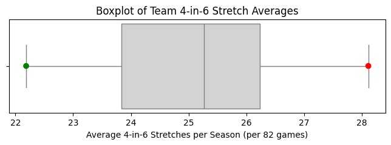

```python
# Z-score for max and min teams
z_max = (most_stretches_value - values.mean()) / values.std()
z_min = (fewest_stretches_value - values.mean()) / values.std()
print(f"Z-score for most (CHA): {z_max:.2f}")
print(f"Z-score for least (NYK): {z_min:.2f}")

# Test for normality
stat, p_normal = stats.shapiro(values)
print(f"Shapiro-Wilk test for normality: p-value = {p_normal:.3f}")

# Outlier test (Grubbs' test for max and min)
def grubbs_test(values, extreme):
    N = len(values)
    mean = values.mean()
    std = values.std()
    G = abs(extreme - mean) / std
    # Critical value for alpha=0.05
    t = stats.t.ppf(1-0.05/(2*N), N-2)
    G_crit = ((N-1)/np.sqrt(N)) * np.sqrt(t**2/(N-2+t**2))
    return G, G_crit

G_max, G_crit_max = grubbs_test(values, most_stretches_value)
G_min, G_crit_min = grubbs_test(values, fewest_stretches_value)
print(f"Grubbs' test statistic for max: {G_max:.2f} (critical: {G_crit_max:.2f})")
print(f"Grubbs' test statistic for min: {G_min:.2f} (critical: {G_crit_min:.2f})")

# Boxplot for visual outlier detection
plt.figure(figsize=(8,2))
sns.boxplot(x=values, color='lightgray')
plt.scatter([most_stretches_value, fewest_stretches_value], [0,0], color=['red','green'], zorder=5)
plt.title('Boxplot of Team 4-in-6 Stretch Averages')
plt.xlabel('Average 4-in-6 Stretches per Season (per 82 games)')
plt.show()
```

**ANSWER 4:**

### Question 5

**QUESTION:** What was BKN's defensive eFG% in the 2023-24 season? What was their defensive eFG% that season in situations where their opponent was on the second night of back-to-back?

```python
# Filter for games where BKN is the defensive team in the 2023-24 season
bkn_def = game_data[(game_data['def_team'] == 'BKN') & (game_data['season'] == 2023)]

# Calculate eFG% (eFG% equation was defined using my own research/prior knowledge since I did not see it defined in the data dictionary)
efg = (bkn_def['fgmade'].sum() + 0.5 * bkn_def['fg3made'].sum()) / bkn_def['fgattempted'].sum()
print(f"BKN Defensive eFG% in 2023-24: {efg * 100:.1f}%")
```

```
BKN Defensive eFG% in 2023-24: 54.3%
```

```python
# Get all games in 2023 for each team
game_data['gamedate'] = pd.to_datetime(game_data['gamedate'])
games_2023 = game_data[game_data['season'] == 2023].copy()

# For each BKN defensive game, check if off_team played the previous day
bkn_def['gamedate'] = pd.to_datetime(bkn_def['gamedate'])
b2b_mask = []
for idx, row in bkn_def.iterrows():
    off_team = row['off_team']
    game_date = row['gamedate']
    # Find previous game for off_team before this date
    team_games = games_2023[(games_2023['off_team'] == off_team) | (games_2023['def_team'] == off_team)]
    team_games = team_games[team_games['gamedate'] < game_date]
    if not team_games.empty:
        prev_game_date = team_games['gamedate'].max()
        # If previous game was exactly one day before, it's a B2B
        b2b_mask.append((game_date - prev_game_date).days == 1)
    else:
        b2b_mask.append(False)

bkn_def['opponent_b2b'] = b2b_mask

# Filter for games where opponent was on a B2B
bkn_b2b_games = bkn_def[bkn_def['opponent_b2b']]

# Calculate eFG% for these games
efg_b2b = (bkn_b2b_games['fgmade'].sum() + 0.5 * bkn_b2b_games['fg3made'].sum()) / bkn_b2b_games['fgattempted'].sum()
print(f"BKN Defensive eFG% when opponent on B2B in 2023-24: {efg_b2b * 100:.1f}%")
```

```
BKN Defensive eFG% when opponent on B2B in 2023-24: 53.5%
```

**ANSWER 5:**

- BKN Defensive eFG%: 54.3%
- When opponent on a B2B: 53.5%

## Part 2 -- Trends and Visualizations

This is an intentionally open ended section, and there are multiple approaches you could take to have a successful project. Feel free to be creative. However, for this section, please consider only the density of games and travel schedule, not the relative on-court strength of different teams.

### Question 6

**QUESTION:** Please identify at least 2 trends in scheduling over time. In other words, how are the more recent schedules different from the schedules of the past? Please include a visual (plot or styled table) highlighting or explaining each trend and include a brief written description of your findings.

**ANSWER 6:**

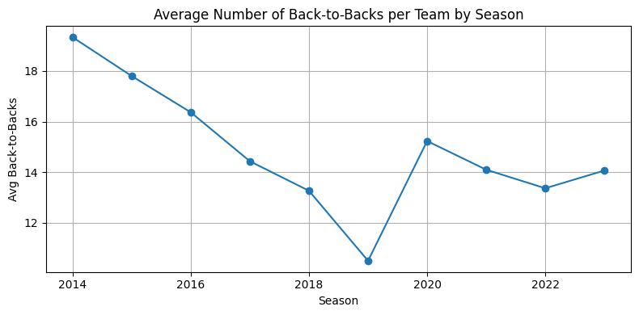

```
Trend 1: The average number of back-to-back games per team has generally decreased over time, indicating the NBA's effort to reduce schedule density and improve player rest. The notable drop in the 2019-20 season is likely due to the COVID-19 pandemic causing schedule disruptions, which lead into th…
```

```python
import numpy as np

import matplotlib.pyplot as plt

# Trend 1: Fewer Back-to-Backs Over Time
schedule['gamedate'] = pd.to_datetime(schedule['gamedate'])
b2b_counts = []
for (team, season), group in schedule.groupby(['team', 'season']):
    group = group.sort_values('gamedate')
    b2b = (group['gamedate'].diff().dt.days == 1).sum()
    b2b_counts.append({'team': team, 'season': season, 'b2b': b2b})
b2b_df = pd.DataFrame(b2b_counts)
b2b_avg = b2b_df.groupby('season')['b2b'].mean()

plt.figure(figsize=(8,4))
plt.plot(b2b_avg.index, b2b_avg.values, marker='o')
plt.title('Average Number of Back-to-Backs per Team by Season')
plt.xlabel('Season')
plt.ylabel('Avg Back-to-Backs')
plt.grid(True)
plt.tight_layout()
plt.show()

# Brief written findings
print("Trend 1: The average number of back-to-back games per team has generally decreased over time, indicating the NBA's effort to reduce schedule density and improve player rest. The notable drop in the 2019-20 season is likely due to the " \
"COVID-19 pandemic causing schedule disruptions, which lead into the following season's sudden spike back up since it was also a reduced year in terms of start and end dates.")
```

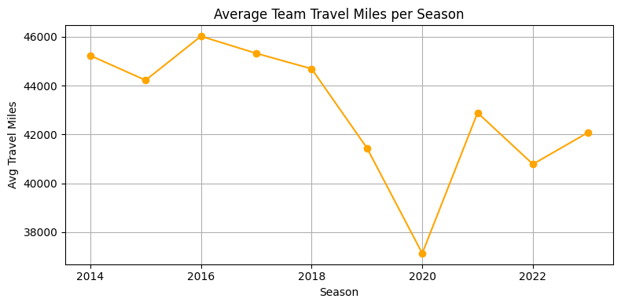

```
Trend 2: The average travel distance per team per season has remained relatively stable, but some recent seasons show a slight decrease, possibly due to more regional scheduling and reduced cross-country trips. Again,the notable drop in the 2020-21 season is likely due to the COVID-19 pandemic causi…
```

```python
# Trend 2: Average Travel Distance Per Team Per Season
def haversine(lat1, lon1, lat2, lon2):
    R = 3959  # miles
    lat1, lon1, lat2, lon2 = map(np.radians, [lat1, lon1, lat2, lon2])
    dlat = lat2 - lat1
    dlon = lon2 - lon1
    a = np.sin(dlat/2)**2 + np.cos(lat1)*np.cos(lat2)*np.sin(dlon/2)**2
    return 2 * R * np.arcsin(np.sqrt(a))

loc_map = locations.set_index('team')[['latitude', 'longitude']].to_dict('index')
travel_stats = []
for (team, season), group in schedule.groupby(['team', 'season']):
    group = group.sort_values('gamedate')
    # If home == 1, use team, else use opponent
    cities = np.where(group['home'] == 1, team, group['opponent'])
    coords = [loc_map.get(t, {'latitude': None, 'longitude': None}) for t in cities]
    lats = [c['latitude'] for c in coords]
    lons = [c['longitude'] for c in coords]
    dist = sum(haversine(lats[i], lons[i], lats[i+1], lons[i+1]) for i in range(len(lats)-1) if None not in (lats[i], lons[i], lats[i+1], lons[i+1]))
    travel_stats.append({'team': team, 'season': season, 'total_miles': dist})
travel_df = pd.DataFrame(travel_stats)
travel_avg = travel_df.groupby('season')['total_miles'].mean()

plt.figure(figsize=(8,4))
plt.plot(travel_avg.index, travel_avg.values, marker='o', color='orange')
plt.title('Average Team Travel Miles per Season')
plt.xlabel('Season')
plt.ylabel('Avg Travel Miles')
plt.grid(True)
plt.tight_layout()
plt.show()

# Brief written findings
print("Trend 2: The average travel distance per team per season has remained relatively stable, but some recent seasons show a slight decrease, possibly due to more regional scheduling and reduced cross-country trips. Again,the notable" \
" drop in the 2020-21 season is likely due to the COVID-19 pandemic causing restrictions and possible stigmas against excessive traveling at the time, as well as a reduced number of games for the season.")
```

### Question 7

**QUESTION:** Please design a plotting tool to help visualize a team’s schedule for a season. The plot should cover the whole season and should help the viewer contextualize and understand a team’s schedule, potentially highlighting periods of excessive travel, dense blocks of games, or other schedule anomalies. If you can, making the plots interactive (for example through the plotly package) is a bonus.

Please use this tool to plot OKC and DEN's provided 80-game 2024-25 schedules.

**ANSWER 7:**

```python
%pip install plotly
```

```python
import plotly.graph_objects as go

def plot_team_schedule_lines(schedule_df, locations_df, team, season):
    # Filter for team and season
    df = schedule_df[(schedule_df['team'] == team) & (schedule_df['season'] == season)].copy()
    df = df.sort_values('gamedate').reset_index(drop=True)
    df['gamedate'] = pd.to_datetime(df['gamedate'])

    # Get city coordinates for each game
    loc_map = locations_df.set_index('team')[['latitude', 'longitude']].to_dict('index')
    cities = np.where(df['home'] == 1, team, df['opponent'])
    coords = [loc_map.get(t, {'latitude': None, 'longitude': None}) for t in cities]
    df['latitude'] = [c['latitude'] for c in coords]
    df['longitude'] = [c['longitude'] for c in coords]

    # Calculate travel distance between games
    def haversine(lat1, lon1, lat2, lon2):
        R = 3959  # miles
        lat1, lon1, lat2, lon2 = map(np.radians, [lat1, lon1, lat2, lon2])
        dlat = lat2 - lat1
        dlon = lon2 - lon1
        a = np.sin(dlat/2)**2 + np.cos(lat1)*np.cos(lat2)*np.sin(dlon/2)**2
        return 2 * R * np.arcsin(np.sqrt(a))
    travel = [0]
    for i in range(1, len(df)):
        if None not in (df.loc[i-1, 'latitude'], df.loc[i-1, 'longitude'], df.loc[i, 'latitude'], df.loc[i, 'longitude']):
            dist = haversine(df.loc[i-1, 'latitude'], df.loc[i-1, 'longitude'], df.loc[i, 'latitude'], df.loc[i, 'longitude'])
        else:
            dist = 0
        travel.append(dist)
    df['travel_miles'] = travel

    # Calculate games in last 6 days (density)
    density = []
    for i in range(len(df)):
        window_start = df.loc[i, 'gamedate'] - pd.Timedelta(days=5)
        games_in_window = ((df['gamedate'] >= window_start) & (df['gamedate'] <= df.loc[i, 'gamedate'])).sum()
        density.append(games_in_window)
    df['games_in_6days'] = density

    # Plot with filled area under lines and dual y-axes
    fig = go.Figure()

    # Game Density (left y-axis)
    fig.add_trace(go.Scatter(
        x=df['gamedate'], y=df['games_in_6days'],
        mode='lines+markers',
        name='Game Density (last 6 days)',
        line=dict(color='blue', width=2),
        marker=dict(size=7),
        fill='tozeroy',
        fillcolor='rgba(0, 100, 255, 0.2)',
        yaxis='y1'
    ))

    # Travel Miles (right y-axis)
    fig.add_trace(go.Scatter(
        x=df['gamedate'], y=df['travel_miles'],
        mode='lines+markers',
        name='Travel Miles',
        line=dict(color='orange', width=2),
        marker=dict(size=7),
        fill='tozeroy',
        fillcolor='rgba(255, 165, 0, 0.2)',
        yaxis='y2'
    ))

    fig.update_layout(
        title=f"{team} {season} Schedule: Game Density & Travel Miles",
        xaxis_title="Date",
        yaxis=dict(
            title="Games in Last 6 Days",
            side='left',
            showgrid=False,
            zeroline=False
        ),
        yaxis2=dict(
            title="Travel Miles",
            side='right',
            overlaying='y',
            showgrid=False,
            zeroline=False
        ),
        legend=dict(x=0.75, y=1.15, orientation='h'),
        height=500,
        width=950
    )
    fig.show()

# Plot OKC and DEN 2024-25 schedules
plot_team_schedule_lines(draft_schedule, locations, 'OKC', 2024)
plot_team_schedule_lines(draft_schedule, locations, 'DEN', 2024)
```

[output not shown]

### Question 8

**QUESTION:** Using your tool, what is the best and worst part of OKC’s 2024-25 draft schedule? Please give your answer as a short brief to members of the front office and coaching staff to set expectations going into the season. You can include context from past schedules.

```python
# Get OKC's average number of 4-in-6 stretches per season (per 82 games) from results_df
okc_stretches = results_df[results_df['team'] == 'OKC'][['season', 'stretches_per_82']]
print(okc_stretches)
```

```
     season  stretches_per_82
200    2014         34.000000
201    2015         26.000000
202    2016         26.000000
203    2017         18.000000
204    2018         18.000000
205    2019         23.916667
206    2020         37.583333
207    2021         25.000000
208    2022         26.000000
209    2023         27.000000
```

```python
# Ensure gamedate is datetime
schedule['gamedate'] = pd.to_datetime(schedule['gamedate'])

# Get OKC games from schedule
okc_hist = schedule[schedule['team'] == 'OKC'].copy()
okc_hist = okc_hist.sort_values('gamedate').reset_index(drop=True)

# Get location mapping
loc_map = locations.set_index('team')[['latitude', 'longitude']].to_dict('index')

def haversine(lat1, lon1, lat2, lon2):
    R = 3959  # miles
    lat1, lon1, lat2, lon2 = map(np.radians, [lat1, lon1, lat2, lon2])
    dlat = lat2 - lat1
    dlon = lon2 - lon1
    a = np.sin(dlat/2)**2 + np.cos(lat1)*np.cos(lat2)*np.sin(dlon/2)**2
    return 2 * R * np.arcsin(np.sqrt(a))

# Calculate total travel miles for each season
okc_travel = []
for season, group in okc_hist.groupby('season'):
    group = group.sort_values('gamedate')
    cities = np.where(group['home'] == 1, 'OKC', group['opponent'])
    coords = [loc_map.get(t, {'latitude': None, 'longitude': None}) for t in cities]
    lats = [c['latitude'] for c in coords]
    lons = [c['longitude'] for c in coords]
    dist = sum(haversine(lats[i], lons[i], lats[i+1], lons[i+1]) for i in range(len(lats)-1) if None not in (lats[i], lons[i], lats[i+1], lons[i+1]))
    okc_travel.append({'season': season, 'total_miles': dist})

okc_travel_df = pd.DataFrame(okc_travel)
print(okc_travel_df)
```

```
   season   total_miles
0    2014  44155.501730
1    2015  48217.985540
2    2016  50610.585893
3    2017  48825.069501
4    2018  45943.378218
5    2019  41992.960367
6    2020  32276.638302
7    2021  43099.302713
8    2022  43428.385573
9    2023  40170.903785
```

```python
# Calculate total miles traveled by OKC in 2024-25 draft schedule
okc_2024_games = okc_games.sort_values('gamedate').reset_index(drop=True)
cities = np.where(okc_2024_games['home'] == 1, 'OKC', okc_2024_games['opponent'])
lats = [loc_map[t]['latitude'] for t in cities]
lons = [loc_map[t]['longitude'] for t in cities]

def haversine(lat1, lon1, lat2, lon2):
    R = 3959  # miles
    lat1, lon1, lat2, lon2 = map(np.radians, [lat1, lon1, lat2, lon2])
    dlat = lat2 - lat1
    dlon = lon2 - lon1
    a = np.sin(dlat/2)**2 + np.cos(lat1)*np.cos(lat2)*np.sin(dlon/2)**2
    return 2 * R * np.arcsin(np.sqrt(a))

total_miles_2024 = sum(
    haversine(lats[i], lons[i], lats[i+1], lons[i+1])
    for i in range(len(lats)-1)
)

print(f"OKC total miles traveled in 2024-25 draft schedule: {total_miles_2024:.0f}")
print(f"OKC 4-in-6 stretches in 2024-25 draft schedule: {count_4_in_6}")
```

```
OKC total miles traveled in 2024-25 draft schedule: 41451
OKC 4-in-6 stretches in 2024-25 draft schedule: 26
```

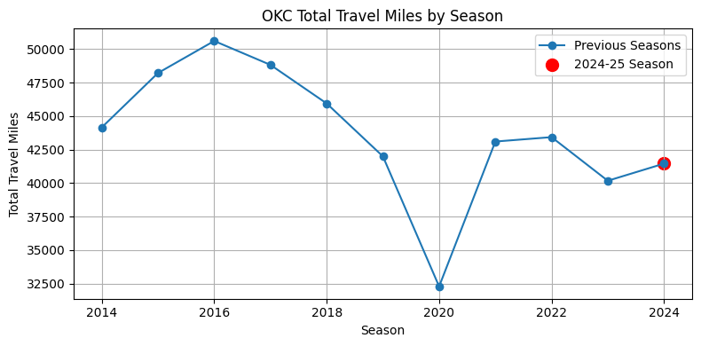

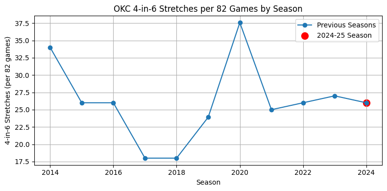

```python
import matplotlib.pyplot as plt
# Append 2024-25 values to historical datasets
okc_travel_df.loc[len(okc_travel_df)] = [2024, total_miles_2024]
okc_stretches.loc[len(okc_stretches)] = [2024, count_4_in_6]

# Plot OKC travel miles by season, highlight 2024-25
plt.figure(figsize=(8,4))
plt.plot(okc_travel_df['season'], okc_travel_df['total_miles'], marker='o', label='Previous Seasons')
plt.scatter(2024, total_miles_2024, color='red', s=100, label='2024-25 Season')
plt.title("OKC Total Travel Miles by Season")
plt.xlabel("Season")
plt.ylabel("Total Travel Miles")
plt.grid(True)
plt.legend()
plt.tight_layout()
plt.show()

# Plot OKC 4-in-6 stretches by season, highlight 2024-25
plt.figure(figsize=(8,4))
plt.plot(okc_stretches['season'], okc_stretches['stretches_per_82'], marker='o', label='Previous Seasons')
plt.scatter(2024, count_4_in_6, color='red', s=100, label='2024-25 Season')
plt.title("OKC 4-in-6 Stretches per 82 Games by Season")
plt.xlabel("Season")
plt.ylabel("4-in-6 Stretches (per 82 games)")
plt.grid(True)
plt.legend()
plt.tight_layout()
plt.show()
```

**ANSWER 8:**

Generally speaking, compared to the previous 3 years, both the game density and total travel milage remain similar heading into the 2024-25 season.

However, breaking the season down, we can see the following:

- The least game-packed parts of the season seem to come between late November to mid/late December, although those include some periods of longer travels.
- Some of the more dense parts of the season come in early through mid November, most of January, and from late February into mid-March. However, there are longer periods of little to no travel for those November and January blocks.
- February and early March show some spikes in traveling, but late March into early April is a bit more calm with less travel and no 4-in-6 stretches for a little while until the very end of the regular season in mid-April.

## Part 3 -- Modeling

### Question 9

**QUESTION:** Please estimate how many more/fewer regular season wins each team has had due to schedule-related factors from 2019-20 though 2023-24. Your final answer should have one number for each team, representing the total number of wins (not per 82, and not a per-season average). You may consider the on-court strength of the scheduled opponents as well as the impact of travel/schedule density. Please include the teams and estimates for the most helped and most hurt in the answer key.

If you fit a model to help answer this question, please write a paragraph explaining your model, and include a simple model diagnostic (eg a printed summary of a regression, a variable importance plot, etc).

```
Top features by RF importance: ['opp_margin', 'team_last10_win_pct', 'opp_rolling_win_pct', 'season_game_num', 'team_travel_miles', 'opp_travel_miles', 'opp_last10_win_pct']
Regression R^2: 0.38847806203142576
Coefficients: {'opp_margin': np.float64(-0.008125925875787412), 'team_last10_win_pct': np.float64(0.657861171306425), 'opp_rolling_win_pct': np.float64(-0.7525287329650363), 'season_game_num': np.float64(5.0424326068110314e-05), 'team_travel_miles': np.float64(-2.8575026391641778e-05), 'opp_travel_m…
```

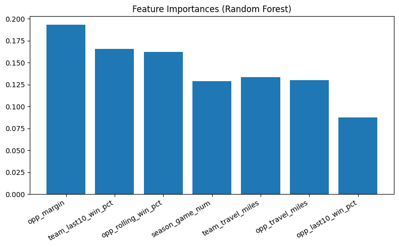

|  | team | schedule_win_diff |
| --- | --- | --- |
| 0 | MIL | 74.209344 |
| 1 | BOS | 70.972302 |
| 2 | DEN | 68.213405 |
| 3 | PHX | 62.073600 |
| 4 | PHI | 58.817068 |
| 5 | LAC | 48.329059 |
| 6 | MIA | 47.193607 |
| 7 | DAL | 40.256519 |
| 8 | LAL | 28.821119 |
| 9 | UTA | 23.039103 |
| 10 | MEM | 17.857390 |
| 11 | BKN | 12.581285 |
| 12 | NYK | 8.648059 |
| 13 | TOR | -1.042112 |
| 14 | CLE | -2.189012 |
| 15 | MIN | -4.775709 |
| 16 | OKC | -13.420714 |
| 17 | GSW | -14.637750 |
| 18 | CHI | -16.642004 |
| 19 | NOP | -18.125618 |
| 20 | IND | -28.670642 |
| 21 | SAC | -29.688720 |
| 22 | ATL | -32.613730 |
| 23 | POR | -35.723617 |
| 24 | ORL | -36.150554 |
| 25 | CHA | -37.452443 |
| 26 | WAS | -60.921186 |
| 27 | SAS | -65.376081 |
| 28 | HOU | -67.193257 |
| 29 | DET | -96.388709 |

```python
from sklearn.linear_model import LinearRegression
from sklearn.ensemble import RandomForestRegressor
from sklearn.metrics import r2_score
import numpy as np

import matplotlib.pyplot as plt

# Merge opponent win% from game_data
opp_win_pct = (
    game_data.groupby(['off_team', 'season'])['off_win']
    .mean()
    .reset_index()
    .rename(columns={'off_team': 'opponent', 'off_win': 'opp_win_pct'})
)
sched = schedule[schedule['season'].isin([2019, 2020, 2021, 2022, 2023])].copy()
sched = sched.merge(opp_win_pct, on=['opponent', 'season'], how='left')

# Add travel miles feature
loc_map = locations.set_index('team')[['latitude', 'longitude']].to_dict('index')
sched = sched.sort_values(['team', 'gamedate'])
sched['latitude'] = sched.apply(lambda r: loc_map[r['team']]['latitude'] if r['home'] == 1 else loc_map[r['opponent']]['latitude'], axis=1)
sched['longitude'] = sched.apply(lambda r: loc_map[r['team']]['longitude'] if r['home'] == 1 else loc_map[r['opponent']]['longitude'], axis=1)
sched['prev_latitude'] = sched.groupby('team')['latitude'].shift(1)
sched['prev_longitude'] = sched.groupby('team')['longitude'].shift(1)
def haversine(lat1, lon1, lat2, lon2):
    R = 3959
    lat1, lon1, lat2, lon2 = map(np.radians, [lat1, lon1, lat2, lon2])
    dlat = lat2 - lat1
    dlon = lon2 - lon1
    a = np.sin(dlat/2)**2 + np.cos(lat1)*np.cos(lat2)*np.sin(dlon/2)**2
    return 2 * R * np.arcsin(np.sqrt(a))
sched['travel_miles'] = sched.apply(
    lambda r: haversine(r['prev_latitude'], r['prev_longitude'], r['latitude'], r['longitude'])
    if pd.notnull(r['prev_latitude']) else 0, axis=1
)

# Add back-to-back feature
sched = sched.sort_values(['team', 'gamedate'])
sched['gamedate'] = pd.to_datetime(sched['gamedate'])
sched['prev_gamedate'] = sched.groupby('team')['gamedate'].shift(1)
sched['back_to_back'] = (sched['gamedate'] - sched['prev_gamedate']).dt.days == 1
sched['back_to_back'] = sched['back_to_back'].astype(int)

# Add rolling opponent win% (last 10 games before each game)
game_data['gamedate'] = pd.to_datetime(game_data['gamedate'])
game_data = game_data.sort_values(['off_team', 'gamedate'])
game_data['opp_rolling_win_pct'] = (
    game_data.groupby('off_team')['off_win']
    .transform(lambda x: x.rolling(window=10, min_periods=1).mean())
)
sched = sched.merge(
    game_data[['gamedate', 'off_team', 'opp_rolling_win_pct']],
    left_on=['gamedate', 'opponent'],
    right_on=['gamedate', 'off_team'],
    how='left'
)

# Add opponent margin of victory (last game)
game_data['opp_margin'] = game_data['points'] - game_data.groupby('off_team')['points'].shift(1)
sched = sched.merge(
    game_data[['gamedate', 'off_team', 'opp_margin']],
    left_on=['gamedate', 'opponent'],
    right_on=['gamedate', 'off_team'],
    how='left'
)

# Add more candidate features
sched['home_advantage'] = sched['home']
sched['season_game_num'] = sched.groupby(['team', 'season']).cumcount() + 1
sched['is_weekend'] = sched['gamedate'].dt.weekday.isin([5, 6]).astype(int)
sched['opp_travel_miles'] = sched.groupby(['opponent', 'season'])['travel_miles'].transform('sum') / sched.groupby(['opponent', 'season'])['travel_miles'].transform('count')
sched['team_travel_miles'] = sched.groupby(['team', 'season'])['travel_miles'].transform('sum') / sched.groupby(['team', 'season'])['travel_miles'].transform('count')
sched['team_win_pct_season'] = sched.groupby(['team', 'season'])['win'].transform('mean')
sched['opp_win_pct_season'] = sched.groupby(['opponent', 'season'])['win'].transform('mean')
sched['team_last10_win_pct'] = sched.groupby('team')['win'].transform(lambda x: x.rolling(window=10, min_periods=1).mean())
sched['opp_last10_win_pct'] = sched.groupby('opponent')['win'].transform(lambda x: x.rolling(window=10, min_periods=1).mean())

# Candidate features
candidate_features = [
    'back_to_back', 'travel_miles', 'opp_win_pct', 'opp_rolling_win_pct', 'opp_margin',
    'home_advantage', 'season_game_num', 'is_weekend', 'opp_travel_miles', 'team_travel_miles',
    'team_win_pct_season', 'opp_win_pct_season', 'team_last10_win_pct', 'opp_last10_win_pct'
]

# Drop rows with missing values in candidate features
sched = sched.dropna(subset=candidate_features + ['win'])

# Feature selection using Random Forest importance
X_full = sched[candidate_features]
y_full = sched['win']
rf_full = RandomForestRegressor(n_estimators=100, random_state=42)
rf_full.fit(X_full, y_full)
importances_full = rf_full.feature_importances_

# Select top N features by importance
N = 7
top_features = [f for _, f in sorted(zip(importances_full, candidate_features), reverse=True)[:N]]

print("Top features by RF importance:", top_features)

# Prepare features and target for regression
X = sched[top_features]
y = sched['win']

# Fit regression model
model = LinearRegression()
model.fit(X, y)
y_pred = model.predict(X)
print("Regression R^2:", r2_score(y, y_pred))
print("Coefficients:", dict(zip(top_features, model.coef_)))

# Variable importance with Random Forest
rf = RandomForestRegressor(n_estimators=100, random_state=42)
rf.fit(X, y)
importances = rf.feature_importances_
plt.figure(figsize=(8, 5))
plt.bar(top_features, importances)
plt.title("Feature Importances (Random Forest)")
plt.xticks(rotation=30, ha='right')
plt.tight_layout()
plt.show()

# Estimate schedule impact: predict win probability with actual vs. "neutral" schedule
sched['pred_actual'] = model.predict(X)
X_neutral = X.copy()
for f in top_features:
    X_neutral[f] = X[f].mean()
sched['pred_neutral'] = model.predict(X_neutral)
sched['schedule_win_diff'] = sched['pred_actual'] - sched['pred_neutral']

# Aggregate by team
team_schedule_impact = sched.groupby('team')['schedule_win_diff'].sum().sort_values(ascending=False)
team_schedule_impact_df = team_schedule_impact.reset_index()
team_schedule_impact_df.columns = ['team', 'schedule_win_diff']
display(team_schedule_impact_df)
```

**ANSWER 9:**